# [SAD] Projekt 2

Banzekulivakha Zhan, Ostoja-Lniski Robert

09-06-2021

## Struktura projektu

Struktura katalogów w projekcie przedstawia się nastepująco:

- data - katalog przechowyjący dane
- info - katalog przechowujący pliki z treścią zadania
- renv - katalog odpowiedzialny ze wirtulane środowisko języka R
- projekt2.Rmd - główny plik (notatnik) zawierajcy kod źródłowy
- projekt2.html - plik wynikowy projekt1.Rmd
- inne pliki konfiguracjne

## Wymagane biblioteki i konfiguracja pakietu *knit*

Poniżej linkwoane bibliteki są wymagane do poprawnej “kompilacji” notatnika, stąd też wymagana jest ich wcześniejsza instalacja. W projekcie użyliśmy biblioteki readxl do wczytywania plików o rozszerzeniu xlsx oraz xls, ggplot2 do pomocniczej wizualizacji, także dplyr do operacji na dataframe.

```r
library("readxl")
library(ggplot2)
library(dplyr)


knitr::opts_chunk$set(echo = TRUE)
```

## Zadanie 1a

Sprawdz, czy proces szczepien przeciw SARS-CoV-2 przebiega równie szybko we wszystkich województwach, tzn. czy liczba szczepien jest proporcjonalna do populacji tych wojewdództw.

### Przygotowanie danych

Sekcja ta definiuje funkcje odpowiedzilne za odpowiednie wczytanie danych i ich przygotowanie.

- read_vaccination_data - wczytuje dane odnośnie szczepień z arkusza kalkulacyjnego
- read_population_data - wczytuje informacje o populacji danego województwa. Pobraliśmy w tym celu dodatkowy, ogólno dostępny zbiór danych statystycznych ze strony https://stat.gov.pl
- area_to_population - otrzymując województwo na wejściu zwraca jego populację
- count_vaccined_to_population - Dla każdego województwa oblicza stosunek sumarycznej liczby osób zaszczepionych (całkowicie) danego dnia do populacji
- read_current_vaccination_data - odczytuje dane o szczepienach z ostatniego pomiaru

```r
read_vaccination_data <- function(data_dir, data_file) {
  data_file_path <- paste0(data_dir, data_file)
  df <- read_excel(data_file_path, sheet="dane", range = "AG4:BL165")
  df_dates <- read_excel(data_file_path, sheet="dane", range = "A4:A165")
  colnames(df_dates) <- c("date")
  df$date <- as.Date(df_dates$date, format = '%Y-%m-%d')
  colnames(df) <- c("dolnoslaskie_ogolem","dolnoslaskie_calkowicie",
                    "kujawskopomorskie_ogolem", "kujawskopomorskie_calkowicie",
                    "lubelskie_ogolem", "lubelskie_calkowicie",
                    "lubuskie_ogolem", "lubuskie_calkowicie",
                    "lodzkie_ogolem", "lodzkie_calkowicie",
                    "malopolskie_ogolem", "malopolskie_calkowicie",
                    "mazowieckie_ogolem", "mazowieckie_calkowicie",
                    "opolskie_ogolem", "opolskie_calkowicie",
                    "podkarpackie_ogolem", "podkarpackie_calkowicie",
                    "podlaskie_ogolem", "podlaskie_calkowicie",
                    "pomorskie_ogolem", "pomorskie_calkowicie",
                    "slaskie_ogolem", "slaskie_calkowicie",
                    "swietokrzyskie_ogolem", "swietokrzyskie_calkowicie",
                    "warminskomazurskie_ogolem", "warminskomazurskie_calkowicie",
                    "wielkopolskie_ogolem", "wielkopolskie_calkowicie",
                    "zachodniopomorskie_ogolem", "zachodniopomorskie_calkowicie",
                    "date")
  df <- df[-c(2:18, 20:21),]
  return(df)
}

read_population_data <- function(data_dir, data_file) {
  data_file_path <- paste0(data_dir, data_file)
  df <- read_excel(data_file_path, sheet="TABL.1", range = "E10:E26")
  colnames(df) <- c("population")
  area_name <- c("dolnoslaskie",
                  "kujawskopomorskie",
                  "lubelskie",
                  "lubuskie",
                  "lodzkie",
                  "malopolskie",
                  "mazowieckie",
                  "opolskie",
                  "podkarpackie",
                  "podlaskie",
                  "pomorskie",
                  "slaskie",
                  "swietokrzyskie",
                  "warminskomazurskie",
                  "wielkopolskie",
                  "zachodniopomorskie")
  df["area"] <- area_name
  return(df)
}

area_to_population <- function(population_data, area_info) {
  area_name <- gsub("\\_.*","",area_info)
  area_population <- population_data$population[ population_data$area==area_name ]
  return(area_population)
}

count_vaccined_to_population <- function(population_data, vaccination_data) {
  data_column_names <- names(vaccination_data)
  data_column_names <- data_column_names[ data_column_names != 'date']
  for(i in data_column_names) {
    area_population <- area_to_population(population_data, i)
    vaccination_data[[i]] <- as.numeric(as.character(vaccination_data[[i]])) / area_population * 100
  }

  return(vaccination_data)
}

read_current_vaccination_data <- function(data_dir, data_file) {
  data_file_path <- paste0(data_dir, data_file)
  df <- read_excel(data_file_path, sheet="DEMOGRAFIA", range = "J4:O19")
  colnames(df) <- c("wojewodztwo", "blanks", "zaszczepionych_niepelnie",
                    "procent_zaszczepionych_niepelnie","zaszczepionych", "procent_zaszczepionych")
  df <- df %>% select("wojewodztwo", "zaszczepionych", "procent_zaszczepionych")
  df["szacunkowa_populacja"] <- df$zaszczepionych / df$procent_zaszczepionych
  return(df)
}
```

### Pomocnicza wizualizacja

W celu lepszej analizy, zdecydowaliśmy się przed wykonaniem testów zwizualizować dane, aby poznać spodziewane wyniki. Poniższy kod jest odpowiedzialny za porównanie przebiegu szczepień i zaprezentowanie go na wykresie

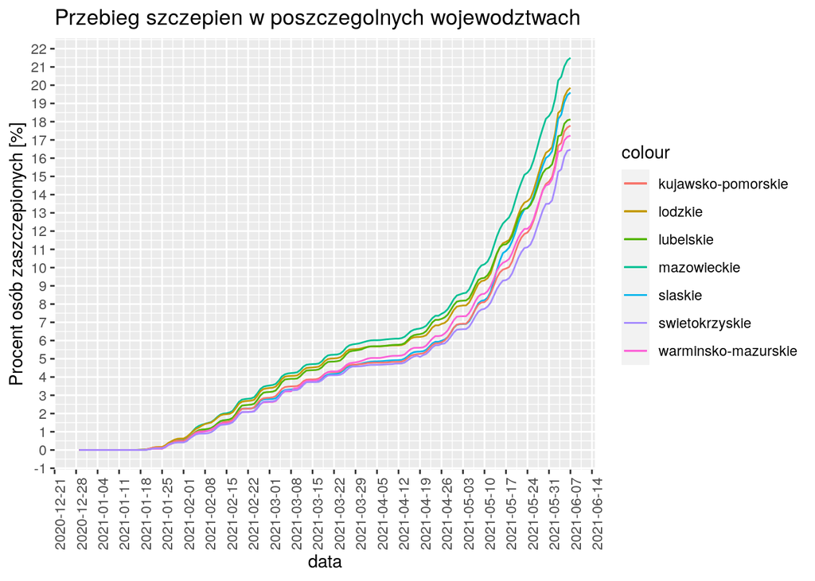

```r
vaccination_data <- read_vaccination_data(data_dir = "data/", data_file = "covid_szczepienia.xlsx")
population_data <- read_population_data(data_dir = "data/", data_file = "ludnosc.xls")
vaccination_data <- count_vaccined_to_population(population_data, vaccination_data)

vaccination_data_total <- vaccination_data %>% select(ends_with("calkowicie"), "date")

ggplot(vaccination_data_total, aes(date)) +
  geom_line(aes(y = mazowieckie_calkowicie,color = "mazowieckie")) +
  geom_line(aes(y = lodzkie_calkowicie,color = "lodzkie")) +
  geom_line(aes(y = slaskie_calkowicie,color = "slaskie")) +
  geom_line(aes(y = lubelskie_calkowicie,color = "lubelskie")) +
  geom_line(aes(y = kujawskopomorskie_calkowicie,color = "kujawsko-pomorskie")) +
  geom_line(aes(y = warminskomazurskie_calkowicie,color = "warminsko-mazurskie")) +
  geom_line(aes(y = swietokrzyskie_calkowicie,color = "swietokrzyskie")) +
  scale_y_continuous(breaks = scales::pretty_breaks(n = 20)) +
  scale_x_date(breaks = "1 week") +
  theme(axis.text.x = element_text(angle = 90, hjust=1)) +
  labs(
    title = "Przebieg szczepien w poszczegolnych wojewodztwach",
    x = "data",
    y = "Procent osób zaszczepionych [%]"
  )
```

Wykres wskazuje bardzo zbliżony postęp szczepień we wszystkich badanych województwach. Między niektórymi województwami, przykładowo mazowieckim i świętokrzyskim, występuje różnica rzędu kilku procent. Z drugiej strony porównując przebieg szczepień w województwie łódzkim i śląskim różnice nieznaczne. Spodziewamy się, że wynik testu hipotezy, że proces szczepień przebiega równie szybko we wszystkich województwach będzie inny badając parę województwo mazowieckie - województwo świętorzyskie niż w przypadku województwo łódzkie - województwo śląskie.

### Testowanie hipotezy

#### Treść hipotezy

- *Hipoteza zerowa* Proces szczepień przebiega równie szybko we wszystkich województwach
- *Hipoteza alternatywna* Proces szczepeiń nie przebiega równie szybko we wszystkich województwach

Przeprowadzamy test Chisq na całym zbiorze województw, a następnie na parach. W tym celu zaimplementowaliśmy funkcje:

- test_full_vacc - testuje wszystkie województwa dostarczone jako lista tested_areas. Na wejściu przyjmuje poziom istotności oraz flagę verbose. Jeśli jest zapalona, to wyświetlany jest pełny wynik testu.
- test_pair_vacc - testuje parę województw, przyjmuje ich nazwę na wejściu
- test_every_pair_vacc - uruchamia dla każdej możliwej pary województw test_pair_vacc

```r
test_full_vacc <- function(df, tested_areas, p_val, verbose) {
  to_test <- df %>% filter(wojewodztwo %in% tested_areas)
  p <- to_test$szacunkowa_populacja / sum(to_test$szacunkowa_populacja)
  res <- chisq.test(to_test$zaszczepionych, p=p)

  if(verbose == 1) {
    print(res)
  }

  if(res$p.value > p_val) {
    result_str <- paste("niezalezne dla p=", p_val)
  } else {
    result_str <- paste("zalezne dla p=", p_val)
  }

  if(res$p.value ==0) {
    msg <- "chisq.p-val pomijalnie małe"
  } else {
    msg <- paste("wyznaczono p-val=", res$p.value)
  }

  print(paste("Szczepienie przeciwko covid we wszystkich badanych wojewodztwach jest", result_str, msg))

}

test_pair_vacc <- function(df, label1, label2, p_val, verbose) {
  to_test <- df %>% filter(wojewodztwo %in% tested_areas)
  p <- to_test$szacunkowa_populacja / sum(to_test$szacunkowa_populacja)
  res <- chisq.test(to_test$zaszczepionych, p=p)

  if(verbose == 1) {
    print(res)
  }

  if(res$p.value > p_val) {
    result_str <- paste("niezalezne dla p=", p_val)
  } else {
    result_str <- paste("zalezne dla p=", p_val)
  }

  if(res$p.value ==0) {
    msg <- "chisq.p-val pomijalnie małe"
  } else {
    msg <- paste("wyznaczono p-val=", res$p.value)
  }

  print(paste("Szczepienie:", label1, "i", label2, "jest", result_str, msg))

}

test_every_pair_vacc <- function(curation_data, tested_areas, p_val, verbose) {
  for(i in 1:(length(tested_areas) - 1)) {
    for (j in (i+1):length(tested_areas)) {
      test_pair_vacc(curation_data, tested_areas[[i]][1], tested_areas[[j]][1], p_val, verbose)
    }
  }
}



current_vaccination_data <- read_current_vaccination_data(data_dir = "data/", data_file = "covid_szczepienia.xlsx")
tested_areas <-  list("mazowieckie", "łódzkie", "śląskie", "lubelskie", "kujawsko-pomorskie", "warmińsko-mazurskie", "świętokrzyskie")
test_full_vacc(current_vaccination_data, tested_areas, 0.05, 1)
```

```
##
##  Chi-squared test for given probabilities
##
## data:  to_test$zaszczepionych
## X-squared = 20152, df = 6, p-value < 2.2e-16
##
## [1] "Szczepienie przeciwko covid we wszystkich badanych wojewodztwach jest zalezne dla p= 0.05 chisq.p-val pomijalnie małe"
```

```r
test_every_pair_vacc(current_vaccination_data, tested_areas, 0.05, 0)
```

```
## [1] "Szczepienie: mazowieckie i łódzkie jest zalezne dla p= 0.05 chisq.p-val pomijalnie małe"
## [1] "Szczepienie: mazowieckie i śląskie jest zalezne dla p= 0.05 chisq.p-val pomijalnie małe"
## [1] "Szczepienie: mazowieckie i lubelskie jest zalezne dla p= 0.05 chisq.p-val pomijalnie małe"
## [1] "Szczepienie: mazowieckie i kujawsko-pomorskie jest zalezne dla p= 0.05 chisq.p-val pomijalnie małe"
## [1] "Szczepienie: mazowieckie i warmińsko-mazurskie jest zalezne dla p= 0.05 chisq.p-val pomijalnie małe"
## [1] "Szczepienie: mazowieckie i świętokrzyskie jest zalezne dla p= 0.05 chisq.p-val pomijalnie małe"
## [1] "Szczepienie: łódzkie i śląskie jest zalezne dla p= 0.05 chisq.p-val pomijalnie małe"
## [1] "Szczepienie: łódzkie i lubelskie jest zalezne dla p= 0.05 chisq.p-val pomijalnie małe"
## [1] "Szczepienie: łódzkie i kujawsko-pomorskie jest zalezne dla p= 0.05 chisq.p-val pomijalnie małe"
## [1] "Szczepienie: łódzkie i warmińsko-mazurskie jest zalezne dla p= 0.05 chisq.p-val pomijalnie małe"
## [1] "Szczepienie: łódzkie i świętokrzyskie jest zalezne dla p= 0.05 chisq.p-val pomijalnie małe"
## [1] "Szczepienie: śląskie i lubelskie jest zalezne dla p= 0.05 chisq.p-val pomijalnie małe"
## [1] "Szczepienie: śląskie i kujawsko-pomorskie jest zalezne dla p= 0.05 chisq.p-val pomijalnie małe"
## [1] "Szczepienie: śląskie i warmińsko-mazurskie jest zalezne dla p= 0.05 chisq.p-val pomijalnie małe"
## [1] "Szczepienie: śląskie i świętokrzyskie jest zalezne dla p= 0.05 chisq.p-val pomijalnie małe"
## [1] "Szczepienie: lubelskie i kujawsko-pomorskie jest zalezne dla p= 0.05 chisq.p-val pomijalnie małe"
## [1] "Szczepienie: lubelskie i warmińsko-mazurskie jest zalezne dla p= 0.05 chisq.p-val pomijalnie małe"
## [1] "Szczepienie: lubelskie i świętokrzyskie jest zalezne dla p= 0.05 chisq.p-val pomijalnie małe"
## [1] "Szczepienie: kujawsko-pomorskie i warmińsko-mazurskie jest zalezne dla p= 0.05 chisq.p-val pomijalnie małe"
## [1] "Szczepienie: kujawsko-pomorskie i świętokrzyskie jest zalezne dla p= 0.05 chisq.p-val pomijalnie małe"
## [1] "Szczepienie: warmińsko-mazurskie i świętokrzyskie jest zalezne dla p= 0.05 chisq.p-val pomijalnie małe"
```

## Zadanie 1b

Sprawdz, czy skutecznosc leczenia osób zarazonych wirusem SARS-CoV-2 jest taka sama na terenie całej Polski, tzn. czy liczba przypadków smiertelnych jest proporcjonalna do liczby osób zarazonych w poszczególnych województwach.

### Przygotowanie danych

Sekcja ta definiuje funkcje odpowiedzilne za odpowiednie wczytanie danych i ich przygotowanie.

- read_curation_data - wczytuje sumaryczne dane odnośnie zgonów
- add_curation_efficiency_column - dodaje do dataframe kolumnę obliczającą procentową jakość leczenia
- read_daily_cases_sum - wczytuje dzienną sumaryczną liczbę przypadków dla każdego województwa
- read_daily_deaths_sum - wczytuje dzienną sumaryczną liczbę zgonów dla każdego województwa

```r
read_curation_data <- function(data_dir, data_file) {
  data_file_path <- paste0(data_dir, data_file)
  df <- read_excel(data_file_path, sheet="Aktualna sytuacja w Polsce", range = "B2:G18")
  colnames(df) <- c("wojewodztwo","suma_potwierdzonych","suma_zgonow","suma_wyzdrowien", "nieaktyne_przypadki", "aktywne_przypadki")
  return(df)
}

add_curation_efficiency_column <- function(df) {
  df <- transform(df, efektywnosc_leczenia = suma_zgonow / suma_potwierdzonych * 100)
  return(df)
}

read_daily_cases_sum <- function(data_dir, data_file) {
  data_file_path <- paste0(data_dir, data_file)
  df <- read_excel(data_file_path, sheet="Wzrost w województwach", range = "B31:QT47")
  df2 <- data.frame(t(df[-1]))
  colnames(df2) <- c("dolnoslaskie",
                  "kujawskopomorskie",
                  "lubelskie",
                  "lubuskie",
                  "lodzkie",
                  "malopolskie",
                  "mazowieckie",
                  "opolskie",
                  "podkarpackie",
                  "podlaskie",
                  "pomorskie",
                  "slaskie",
                  "swietokrzyskie",
                  "warminskomazurskie",
                  "wielkopolskie",
                  "zachodniopomorskie")
  return(df2)
}

read_daily_deaths_sum <- function(data_dir, data_file) {
  data_file_path <- paste0(data_dir, data_file)
  df <- read_excel(data_file_path, sheet="Wzrost w województwach", range = "B71:QT87")
  df2 <- data.frame(t(df[-1]))
  colnames(df2) <- c("dolnoslaskie",
                  "kujawskopomorskie",
                  "lubelskie",
                  "lubuskie",
                  "lodzkie",
                  "malopolskie",
                  "mazowieckie",
                  "opolskie",
                  "podkarpackie",
                  "podlaskie",
                  "pomorskie",
                  "slaskie",
                  "swietokrzyskie",
                  "warminskomazurskie",
                  "wielkopolskie",
                  "zachodniopomorskie")
  return(df2)
}
```

### Pomocnicza wizualizacja

W tym zdaniu również zdecydowaliśmy się na pomocniczą wizualizację. Wykres przedstawia efektywność leczenia pacjentów w najpóźniejszym (najbardziej aktualnym) dniu.

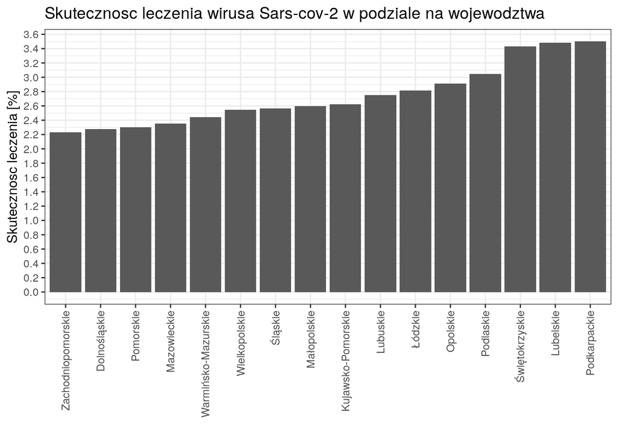

```r
curation_data <- read_curation_data(data_dir = "data/", data_file = "covid_w_polsce.xlsx")
curation_data <- add_curation_efficiency_column(curation_data)
curation_data <- curation_data[order(curation_data$efektywnosc_leczenia),]

draw_efficiency_chart <- function(df) {
  ggplot(data=df, aes(wojewodztwo, efektywnosc_leczenia)) +
    theme_bw() +
    geom_bar(stat='identity') +
    scale_y_continuous(breaks = scales::pretty_breaks(n = 20)) +
    theme(axis.text.x = element_text(angle = 90, vjust = 0.5, hjust=1)) +
    scale_x_discrete(limits= df$wojewodztwo) +
    labs(
      title = paste("Skutecznosc leczenia wirusa Sars-cov-2 w podziale na wojewodztwa"),
      x = "",
      y = "Skutecznosc leczenia [%]"
    )
}

draw_efficiency_chart(curation_data)
```

### Testowanie hipotezy

#### Treść hipotezy

- *Hipoteza zerowa* Skuteczność leczenia osób zarażonych wirusem SARS-CoV-2 jest taka sama na terenie całej Polski
- *Hipoteza alternatywna* Skuteczność leczenie osób zarażonych wirusem SARS-CoV-2 nie jest taka sama na terenie całej Polski

- test_pair_eff - wynokuje test Chisq na parze województw określonych parametrami label1 i label2
- test_full_eff - wynokuje test na każdym wojewódzwie z listy
- test_every_pair_eff - uruchamia test_pair_eff dla każdej możliwej pary wyjewództw z zadanej listy

```r
test_pair_eff <- function(df, label1, label2, p_val, verbose) {
  to_test <- df %>% filter(wojewodztwo %in% c(label1, label2))
  to_test <- to_test %>% select("suma_potwierdzonych", "suma_zgonow")
  p <- to_test$suma_potwierdzonych / sum(to_test$suma_potwierdzonych)
  res <- chisq.test(to_test$suma_zgonow, p=p)

  if(verbose == 1) {
    print(res)
  }

  if(res$p.value > p_val) {
    result_str <- paste("niezalezne dla p=", p_val)
  } else {
    result_str <- paste("zalezne dla p=", p_val)
  }
  print(paste("Leczenie:", label1, "i", label2, "jest", result_str, "chisq.p-val=", res$p.value))

}

test_full_eff <- function(df, tested_areas, p_val, verbose) {
  to_test <- df %>% filter(wojewodztwo %in% tested_areas)
  to_test <- to_test %>% select("suma_potwierdzonych", "suma_zgonow")
  p <- to_test$suma_potwierdzonych / sum(to_test$suma_potwierdzonych)
  res <- chisq.test(to_test$suma_zgonow, p=p)

  if(verbose == 1) {
    print(res)
  }

  if(res$p.value > p_val) {
    result_str <- paste("niezalezne dla p=", p_val)
  } else {
    result_str <- paste("zalezne dla p=", p_val)
  }
  print(paste("Leczenie covid we wszystkich badanych wojewodztwach jest", result_str, "wyznaczono p-val=", res$p.value))

}

test_every_pair_eff <- function(curation_data, tested_areas, p_val, verbose) {
  for(i in 1:(length(tested_areas) - 1)) {
    for (j in (i+1):length(tested_areas)) {
      test_pair_eff(curation_data, tested_areas[[i]][1], tested_areas[[j]][1], p_val, verbose)
    }
  }
}


tested_areas <-  list("Mazowieckie", "Łódzkie", "Śląskie", "Lubelskie", "Kujawsko-Pomorskie", "Warmińsko-Mazurskie", "Świętokrzyskie")
test_full_eff(curation_data, tested_areas, 1, 1)
```

```
##
##  Chi-squared test for given probabilities
##
## data:  to_test$suma_zgonow
## X-squared = 672.75, df = 6, p-value < 2.2e-16
##
## [1] "Leczenie covid we wszystkich badanych wojewodztwach jest zalezne dla p= 1 wyznaczono p-val= 4.66083866309187e-142"
```

```r
test_every_pair_eff(curation_data, tested_areas, 0.05, 0)
```

```
## [1] "Leczenie: Mazowieckie i Łódzkie jest zalezne dla p= 0.05 chisq.p-val= 2.16648284456319e-24"
## [1] "Leczenie: Mazowieckie i Śląskie jest zalezne dla p= 0.05 chisq.p-val= 4.02521777367537e-09"
## [1] "Leczenie: Mazowieckie i Lubelskie jest zalezne dla p= 0.05 chisq.p-val= 1.93220759873936e-102"
## [1] "Leczenie: Mazowieckie i Kujawsko-Pomorskie jest zalezne dla p= 0.05 chisq.p-val= 2.41249217452253e-09"
## [1] "Leczenie: Mazowieckie i Warmińsko-Mazurskie jest niezalezne dla p= 0.05 chisq.p-val= 0.0807614942677542"
## [1] "Leczenie: Mazowieckie i Świętokrzyskie jest zalezne dla p= 0.05 chisq.p-val= 9.50754389665259e-64"
## [1] "Leczenie: Łódzkie i Śląskie jest zalezne dla p= 0.05 chisq.p-val= 1.60051406428315e-07"
## [1] "Leczenie: Łódzkie i Lubelskie jest zalezne dla p= 0.05 chisq.p-val= 4.72124957459725e-25"
## [1] "Leczenie: Łódzkie i Kujawsko-Pomorskie jest zalezne dla p= 0.05 chisq.p-val= 0.000418596179512214"
## [1] "Leczenie: Łódzkie i Warmińsko-Mazurskie jest zalezne dla p= 0.05 chisq.p-val= 1.01781189700187e-09"
## [1] "Leczenie: Łódzkie i Świętokrzyskie jest zalezne dla p= 0.05 chisq.p-val= 2.97576174249419e-16"
## [1] "Leczenie: Śląskie i Lubelskie jest zalezne dla p= 0.05 chisq.p-val= 1.44035538899993e-62"
## [1] "Leczenie: Śląskie i Kujawsko-Pomorskie jest niezalezne dla p= 0.05 chisq.p-val= 0.257396627583976"
## [1] "Leczenie: Śląskie i Warmińsko-Mazurskie jest zalezne dla p= 0.05 chisq.p-val= 0.0189223039218727"
## [1] "Leczenie: Śląskie i Świętokrzyskie jest zalezne dla p= 0.05 chisq.p-val= 1.86589416927748e-38"
## [1] "Leczenie: Lubelskie i Kujawsko-Pomorskie jest zalezne dla p= 0.05 chisq.p-val= 3.33669619897157e-42"
## [1] "Leczenie: Lubelskie i Warmińsko-Mazurskie jest zalezne dla p= 0.05 chisq.p-val= 9.79442818909348e-51"
## [1] "Leczenie: Lubelskie i Świętokrzyskie jest niezalezne dla p= 0.05 chisq.p-val= 0.59633972095401"
## [1] "Leczenie: Kujawsko-Pomorskie i Warmińsko-Mazurskie jest zalezne dla p= 0.05 chisq.p-val= 0.00290018333627655"
## [1] "Leczenie: Kujawsko-Pomorskie i Świętokrzyskie jest zalezne dla p= 0.05 chisq.p-val= 4.22356859830588e-28"
## [1] "Leczenie: Warmińsko-Mazurskie i Świętokrzyskie jest zalezne dla p= 0.05 chisq.p-val= 1.80842103170015e-36"
```

### Wnioski

- Śląskie i Kujawsko-Pomorskie (p= 0.05 chisq.p-val= 0.257396627583976)
- Lubelskie i Świętokrzyski (p= 0.05 chisq.p-val= 0.59633972095401)
- Mazowieckie i Warmińsko-Mazurskie (p= 0.05 chisq.p-val= 0.0807614942677542)

## Zadanie 2

#### Zakładamy hipotezę o niezaleznosci wyniku meczu, rozumianego jako zwyciestwo, porazke lub remis gospodarzy, od kraju rozgrywek.

Dane pobrane ze strony fcstats.com.

*Zestaw lig do analizy:* * Super League (Liga chińska) * Premier League (Liga angielska) * Serie A (Liga włoska) * Primera Division (Liga hiszpańska)

Przygotowanie danych do analizy:

```r
data_compare_leagues <- data.frame(matrix(ncol = 4, nrow = 0))
colnames(data_compare_leagues) <- c("name_of_league", "1", "x", "2")
data_compare_leagues[nrow(data_compare_leagues) + 1,] = c("Super League (Liga chińska)", 102, 79, 59)
data_compare_leagues[nrow(data_compare_leagues) + 1,] = c("Premier League (Liga angielska)", 193, 96, 91)
data_compare_leagues[nrow(data_compare_leagues) + 1,] = c("Serie A (Liga włoska)", 186, 102, 92)
data_compare_leagues[nrow(data_compare_leagues) + 1,] = c("Primera Division (Liga hiszpańska)", 194, 95, 91)

rownames(data_compare_leagues) <- data_compare_leagues[,1]
data_compare_leagues[,1] <- NULL

data_compare_leagues$`1` = as.numeric(as.character(data_compare_leagues$`1`))
data_compare_leagues$`x` = as.numeric(as.character(data_compare_leagues$`x`))
data_compare_leagues$`2` = as.numeric(as.character(data_compare_leagues$`2`))
```

### Treść hipotezy

Wartość statystyki testowej Przeprawadzimy test niezależności chi-kwadrat

```r
chi_square_fun <- function(observed_vals, expected_vals) {
  x_2 <- sum((observed_vals-expected_vals) ^ 2 / expected_vals)
  return(x_2)
}

observed <- data_compare_leagues
expected <- outer(rowSums(observed), colSums(observed), "*") / sum(observed)
stats_val <- chi_square_fun(observed, expected)
stats_val
```

```
## [1] 6.787629
```

Wyznaczenia stopnia swobody (**df**) gdzie 3 - to liczba kolumn, a 4 liczba wierszów. Wartość poziomu istotności (**a**) , zgodzie z opisem zadania, ma wynośić 0.05 Określenie wartości krytycznej przy określonym stopniu swobody i poziomu istotności

```r
df <- (3-1)*(4-1)
a <- 0.05
critical_val <- qchisq(a, df)
critical_val
```

```
## [1] 1.635383
```

Wyliczanie p-wartości:

```r
p_val <- pchisq(stats_val, df, lower.tail=FALSE)
p_val
```

```
## [1] 0.3409346
```

```r
if(a > p_val) {
  print(paste("Hipoteza H_0 o zależności się potwierdza.  p=", p_val, " a=", a))
} else {
  print(paste("Hipoteza H_0 się nie potwierdza. p_val=", p_val, "a=", a))
}
```

```
## [1] "Hipoteza H_0 się nie potwierdza. p_val= 0.340934595681236 a= 0.05"
```

#### Sprawdzanie za pomocą funkcji chisq.test

```r
chisq.test(observed, expected)
```

```
##
##  Pearson's Chi-squared test
##
## data:  observed
## X-squared = 6.7876, df = 6, p-value = 0.3409
```